# Laboratorio 6: Regresión logística - Dataset HMEQ

Pablo Cambria

26/06/2026

# 1 Objetivo

Construir y evaluar un modelo de regresión logística para predecir la morosidad de préstamos. La variable `BAD` toma el valor de `0` cuando el préstamo no es moroso y `1` cuando es moroso.

# 2 Declaración de uso de inteligencia artificial

Para esta actividad se utilizó la herramienta de inteligencia artificial ChatGPT, modelo GPT-5.5 High, únicamente para desarrollar y organizar el documento R Markdown. La IA no se utilizó para importar, limpiar ni desarrollar el análisis exploratorio de los datos; tampoco se utilizó para elegir las variables ni ajustar el modelo.

# 3 Librerías e importación de datos

```r
install.packages(c("ggplot2", "caret", "ROCR"))
```

```r
library(ggplot2)
library(caret)
library(ROCR)
```

```r
prestamos <- read.csv(
  "hmeq.csv",
  stringsAsFactors = FALSE,
  na.strings = c("", "NA")
)

str(prestamos)
```

```
## 'data.frame':    5960 obs. of  13 variables:
##  $ BAD    : int  1 1 1 1 0 1 1 1 1 1 ...
##  $ LOAN   : int  1100 1300 1500 1500 1700 1700 1800 1800 2000 2000 ...
##  $ MORTDUE: num  25860 70053 13500 NA 97800 ...
##  $ VALUE  : num  39025 68400 16700 NA 112000 ...
##  $ REASON : chr  "HomeImp" "HomeImp" "HomeImp" NA ...
##  $ JOB    : chr  "Other" "Other" "Other" NA ...
##  $ YOJ    : num  10.5 7 4 NA 3 9 5 11 3 16 ...
##  $ DEROG  : int  0 0 0 NA 0 0 3 0 0 0 ...
##  $ DELINQ : int  0 2 0 NA 0 0 2 0 2 0 ...
##  $ CLAGE  : num  94.4 121.8 149.5 NA 93.3 ...
##  $ NINQ   : int  1 0 1 NA 0 1 1 0 1 0 ...
##  $ CLNO   : int  9 14 10 NA 14 8 17 8 12 13 ...
##  $ DEBTINC: num  NA NA NA NA NA ...
```

```r
summary(prestamos)
```

```
##       BAD              LOAN          MORTDUE           VALUE
##  Min.   :0.0000   Min.   : 1100   Min.   :  2063   Min.   :  8000
##  1st Qu.:0.0000   1st Qu.:11100   1st Qu.: 46276   1st Qu.: 66076
##  Median :0.0000   Median :16300   Median : 65019   Median : 89236
##  Mean   :0.1995   Mean   :18608   Mean   : 73761   Mean   :101776
##  3rd Qu.:0.0000   3rd Qu.:23300   3rd Qu.: 91488   3rd Qu.:119824
##  Max.   :1.0000   Max.   :89900   Max.   :399550   Max.   :855909
##                                   NAs    :518      NAs    :112
##        REASON            JOB            YOJ             DEROG
##  Length   :5960   Length   :5960   Min.   : 0.000   Min.   : 0.0000
##  N.unique :   2   N.unique :   6   1st Qu.: 3.000   1st Qu.: 0.0000
##  N.blank  :   0   N.blank  :   0   Median : 7.000   Median : 0.0000
##  Min.nchar:   7   Min.nchar:   3   Mean   : 8.922   Mean   : 0.2546
##  Max.nchar:   7   Max.nchar:   7   3rd Qu.:13.000   3rd Qu.: 0.0000
##  NAs      : 252   NAs      : 279   Max.   :41.000   Max.   :10.0000
##                                    NAs    :515      NAs    :708
##      DELINQ            CLAGE             NINQ             CLNO
##  Min.   : 0.0000   Min.   :   0.0   Min.   : 0.000   Min.   : 0.0
##  1st Qu.: 0.0000   1st Qu.: 115.1   1st Qu.: 0.000   1st Qu.:15.0
##  Median : 0.0000   Median : 173.5   Median : 1.000   Median :20.0
##  Mean   : 0.4494   Mean   : 179.8   Mean   : 1.186   Mean   :21.3
##  3rd Qu.: 0.0000   3rd Qu.: 231.6   3rd Qu.: 2.000   3rd Qu.:26.0
##  Max.   :15.0000   Max.   :1168.2   Max.   :17.000   Max.   :71.0
##  NAs    :580       NAs    :308      NAs    :510      NAs    :222
##     DEBTINC
##  Min.   :  0.5245
##  1st Qu.: 29.1400
##  Median : 34.8183
##  Mean   : 33.7799
##  3rd Qu.: 39.0031
##  Max.   :203.3121
##  NAs    :1267
```

# 4 Selección y análisis exploratorio de variables

```r
predictores <- c(
  "LOAN", "MORTDUE", "VALUE", "JOB", "DEROG",
  "DELINQ", "CLAGE", "NINQ", "CLNO", "DEBTINC"
)

variables_modelo <- c("BAD", predictores)

# Se conservan todos los préstamos con BAD conocido.
# NO se usa complete.cases() para crear el dataset final.
datos <- prestamos[!is.na(prestamos$BAD), variables_modelo]
datos$BAD <- as.integer(datos$BAD)

datos$JOB <- trimws(as.character(datos$JOB))
datos$JOB[datos$JOB == ""] <- NA

table(datos$BAD)
```

```
##
##    0    1
## 4771 1189
```

```r
prop.table(table(datos$BAD))
```

```
##
##         0         1
## 0.8005034 0.1994966
```

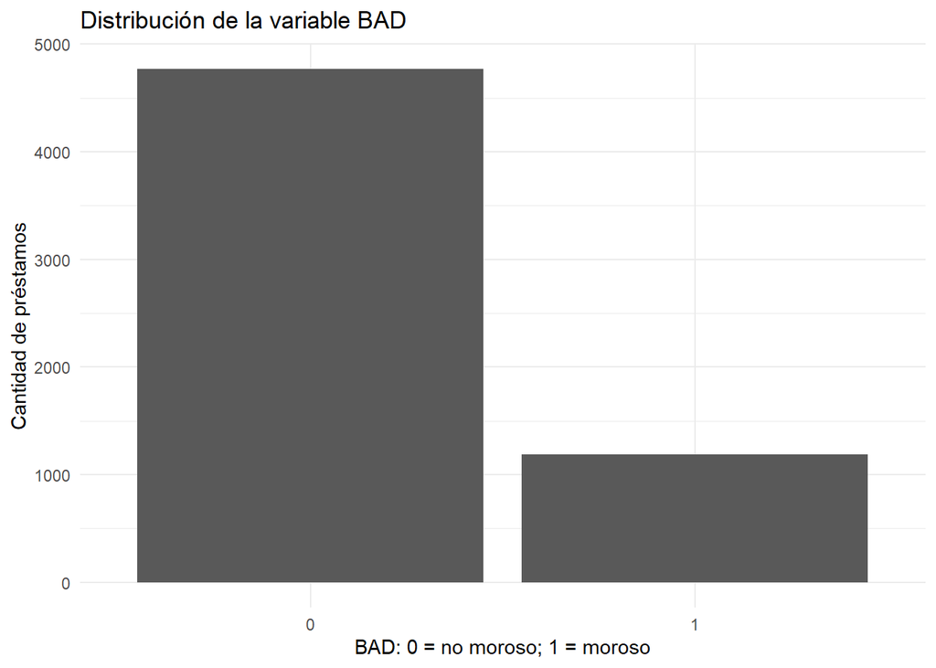

```r
ggplot(datos, aes(x = factor(BAD))) +
  geom_bar() +
  labs(
    title = "Distribución de la variable BAD",
    x = "BAD: 0 = no moroso; 1 = moroso",
    y = "Cantidad de préstamos"
  ) +
  theme_minimal()
```

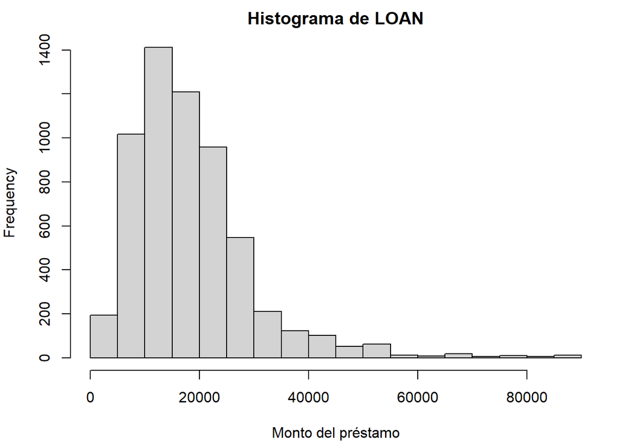

```r
# Se utiliza un solo gráfico por figura para evitar el error:
# Error in plot.new() : figure margins too large
par(mfrow = c(1, 1), mar = c(4, 4, 2, 1))

hist(datos$LOAN,
     breaks = 30,
     main = "Histograma de LOAN",
     xlab = "Monto del préstamo")
```

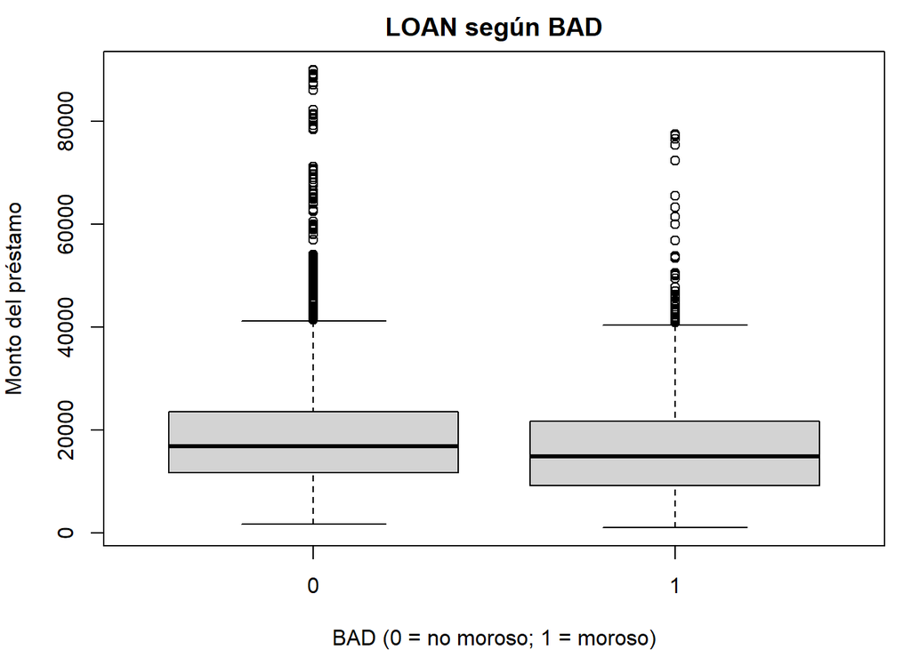

```r
boxplot(LOAN ~ BAD,
        data = datos,
        main = "LOAN según BAD",
        xlab = "BAD (0 = no moroso; 1 = moroso)",
        ylab = "Monto del préstamo",
        names = c("0", "1"))
```

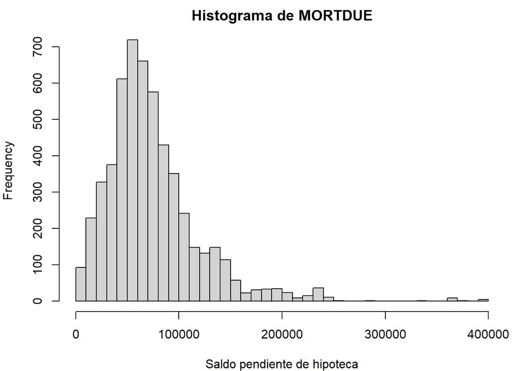

```r
hist(datos$MORTDUE[!is.na(datos$MORTDUE)],
     breaks = 30,
     main = "Histograma de MORTDUE",
     xlab = "Saldo pendiente de hipoteca")
```

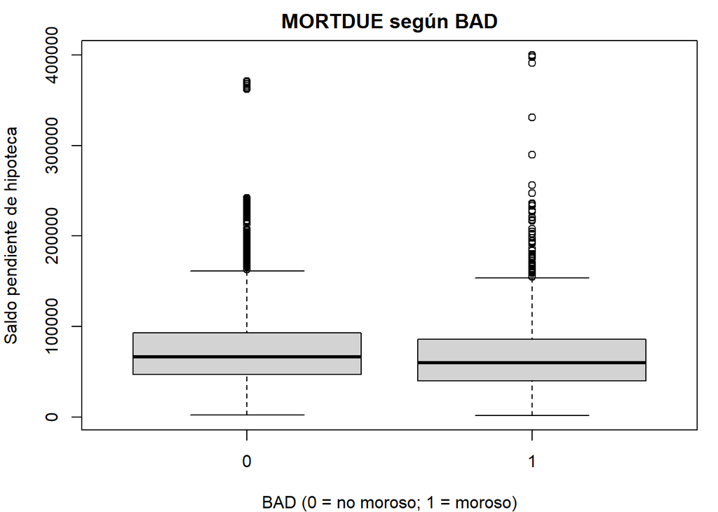

```r
boxplot(MORTDUE ~ BAD,
        data = datos,
        main = "MORTDUE según BAD",
        xlab = "BAD (0 = no moroso; 1 = moroso)",
        ylab = "Saldo pendiente de hipoteca",
        names = c("0", "1"))
```

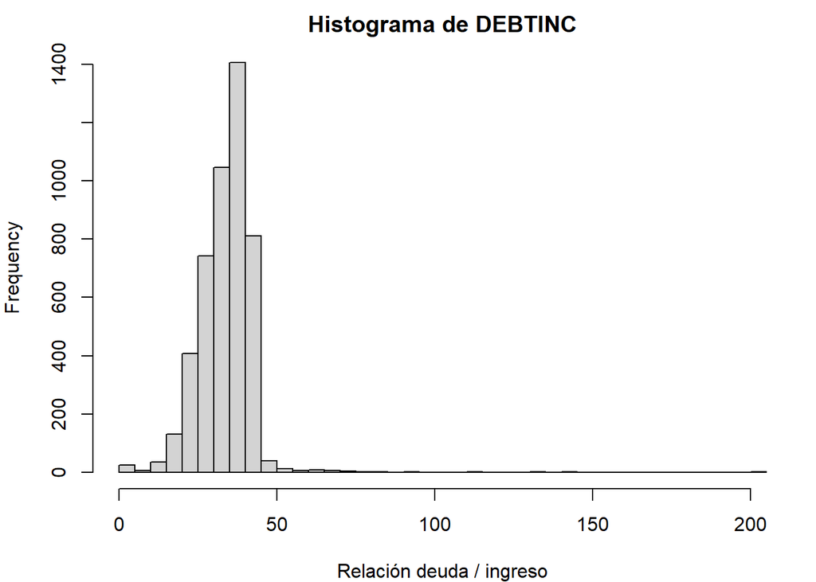

```r
hist(datos$DEBTINC[!is.na(datos$DEBTINC)],
     breaks = 30,
     main = "Histograma de DEBTINC",
     xlab = "Relación deuda / ingreso")
```

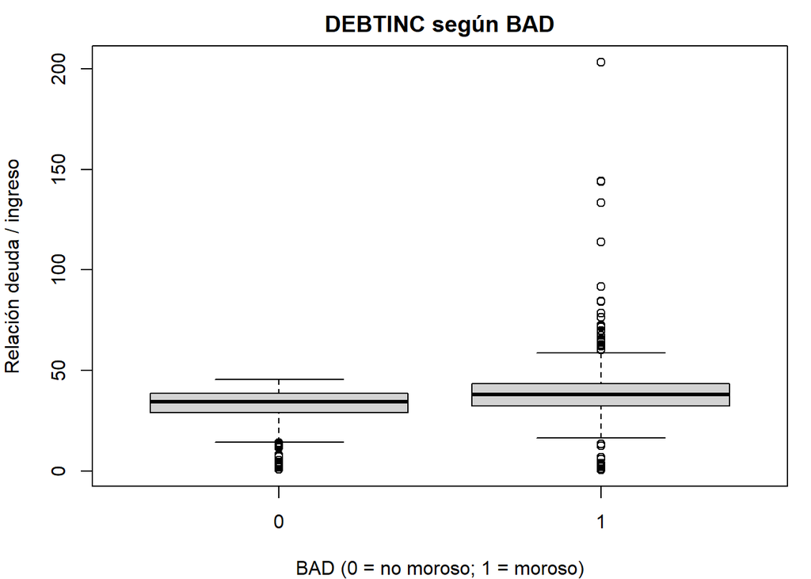

```r
boxplot(DEBTINC ~ BAD,
        data = datos,
        main = "DEBTINC según BAD",
        xlab = "BAD (0 = no moroso; 1 = moroso)",
        ylab = "Relación deuda / ingreso",
        names = c("0", "1"))
```

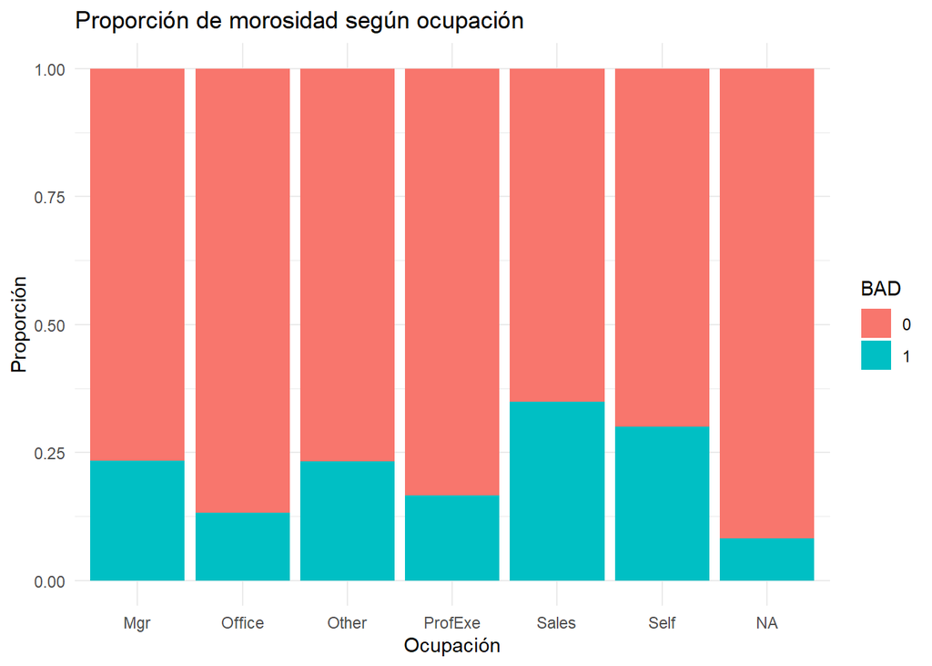

```r
ggplot(datos, aes(x = JOB, fill = factor(BAD))) +
  geom_bar(position = "fill") +
  labs(
    title = "Proporción de morosidad según ocupación",
    x = "Ocupación",
    y = "Proporción",
    fill = "BAD"
  ) +
  theme_minimal()
```

```r
summary(datos[, c("LOAN", "MORTDUE", "VALUE", "DEROG", "DELINQ",
                 "CLAGE", "NINQ", "CLNO", "DEBTINC")])
```

```
##       LOAN          MORTDUE           VALUE            DEROG
##  Min.   : 1100   Min.   :  2063   Min.   :  8000   Min.   : 0.0000
##  1st Qu.:11100   1st Qu.: 46276   1st Qu.: 66076   1st Qu.: 0.0000
##  Median :16300   Median : 65019   Median : 89236   Median : 0.0000
##  Mean   :18608   Mean   : 73761   Mean   :101776   Mean   : 0.2546
##  3rd Qu.:23300   3rd Qu.: 91488   3rd Qu.:119824   3rd Qu.: 0.0000
##  Max.   :89900   Max.   :399550   Max.   :855909   Max.   :10.0000
##                  NAs    :518      NAs    :112      NAs    :708
##      DELINQ            CLAGE             NINQ             CLNO
##  Min.   : 0.0000   Min.   :   0.0   Min.   : 0.000   Min.   : 0.0
##  1st Qu.: 0.0000   1st Qu.: 115.1   1st Qu.: 0.000   1st Qu.:15.0
##  Median : 0.0000   Median : 173.5   Median : 1.000   Median :20.0
##  Mean   : 0.4494   Mean   : 179.8   Mean   : 1.186   Mean   :21.3
##  3rd Qu.: 0.0000   3rd Qu.: 231.6   3rd Qu.: 2.000   3rd Qu.:26.0
##  Max.   :15.0000   Max.   :1168.2   Max.   :17.000   Max.   :71.0
##  NAs    :580       NAs    :308      NAs    :510      NAs    :222
##     DEBTINC
##  Min.   :  0.5245
##  1st Qu.: 29.1400
##  Median : 34.8183
##  Mean   : 33.7799
##  3rd Qu.: 39.0031
##  Max.   :203.3121
##  NAs    :1267
```

## 4.1 Diagnóstico de valores faltantes

```r
tabla_faltantes <- data.frame(
  Variable = predictores,
  NA_BAD_0 = sapply(predictores, function(v) {
    round(mean(is.na(datos[[v]][datos$BAD == 0])) * 100, 2)
  }),
  NA_BAD_1 = sapply(predictores, function(v) {
    round(mean(is.na(datos[[v]][datos$BAD == 1])) * 100, 2)
  })
)

tabla_faltantes
```

```
##         Variable NA_BAD_0 NA_BAD_1
## LOAN        LOAN     0.00     0.00
## MORTDUE  MORTDUE     8.64     8.92
## VALUE      VALUE     0.15     8.83
## JOB          JOB     5.37     1.93
## DEROG      DEROG    13.02     7.32
## DELINQ    DELINQ    10.65     6.06
## CLAGE      CLAGE     4.82     6.56
## NINQ        NINQ     9.12     6.31
## CLNO        CLNO     3.54     4.46
## DEBTINC  DEBTINC    10.08    66.11
```

```r
# Este bloque solo demuestra el sesgo generado por complete.cases().
# No se utilizará para crear el dataset final.
casos_completos <- complete.cases(datos[, variables_modelo])

tabla_conservacion <- prop.table(
  table(BAD = datos$BAD, Caso_completo = casos_completos),
  margin = 1
) * 100

round(tabla_conservacion, 2)
```

```
##    Caso_completo
## BAD FALSE  TRUE
##   0 30.81 69.19
##   1 73.34 26.66
```

```r
prop.table(table(datos$BAD))
```

```
##
##         0         1
## 0.8005034 0.1994966
```

```r
prop.table(table(datos$BAD[casos_completos]))
```

```
##
##          0          1
## 0.91238253 0.08761747
```

La eliminación de registros incompletos cambia la distribución de `BAD`. Esto ocurre principalmente porque `DEBTINC` presenta muchos más valores faltantes entre los préstamos morosos. Por esta razón, se imputarán los faltantes en lugar de eliminar las filas.

# 5 División de los datos y tratamiento de faltantes

```r
set.seed(123)

indice_train <- createDataPartition(
  datos$BAD,
  p = 0.70,
  list = FALSE
)

training_set <- datos[indice_train, ]
test_set <- datos[-indice_train, ]

table(training_set$BAD)
```

```
##
##    0    1
## 3343  829
```

```r
table(test_set$BAD)
```

```
##
##    0    1
## 1428  360
```

```r
prop.table(table(training_set$BAD))
```

```
##
##         0         1
## 0.8012943 0.1987057
```

```r
prop.table(table(test_set$BAD))
```

```
##
##         0         1
## 0.7986577 0.2013423
```

```r
variables_numericas <- c(
  "LOAN", "MORTDUE", "VALUE", "DEROG",
  "DELINQ", "CLAGE", "NINQ", "CLNO", "DEBTINC"
)

# Se identifican las variables numéricas con NA en entrenamiento.
variables_con_na <- variables_numericas[
  colSums(is.na(training_set[, variables_numericas])) > 0
]

# Se crean indicadores de NA antes de imputar.
for (v in variables_con_na) {
  training_set[[paste0(v, "_NA")]] <- as.integer(is.na(training_set[[v]]))
  test_set[[paste0(v, "_NA")]] <- as.integer(is.na(test_set[[v]]))
}

indicadores_na <- paste0(variables_con_na, "_NA")

# Las medianas se calculan solo con entrenamiento y se aplican a prueba.
for (v in variables_numericas) {
  mediana_train <- median(training_set[[v]], na.rm = TRUE)

  training_set[[v]][is.na(training_set[[v]])] <- mediana_train
  test_set[[v]][is.na(test_set[[v]])] <- mediana_train
}

# JOB: los faltantes se convierten en una categoría adicional.
training_set$JOB[is.na(training_set$JOB)] <- "No_informado"
test_set$JOB[is.na(test_set$JOB)] <- "No_informado"

niveles_job <- sort(unique(c(training_set$JOB, "No_informado")))
test_set$JOB[!(test_set$JOB %in% niveles_job)] <- "No_informado"

training_set$JOB <- factor(training_set$JOB, levels = niveles_job)
test_set$JOB <- factor(test_set$JOB, levels = niveles_job)

# Confirmar que no existen NA en las variables que utilizará el modelo.
colSums(is.na(training_set[, c("BAD", predictores, indicadores_na)]))
```

```
##        BAD       LOAN    MORTDUE      VALUE        JOB      DEROG     DELINQ
##          0          0          0          0          0          0          0
##      CLAGE       NINQ       CLNO    DEBTINC MORTDUE_NA   VALUE_NA   DEROG_NA
##          0          0          0          0          0          0          0
##  DELINQ_NA   CLAGE_NA    NINQ_NA    CLNO_NA DEBTINC_NA
##          0          0          0          0          0
```

```r
colSums(is.na(test_set[, c("BAD", predictores, indicadores_na)]))
```

```
##        BAD       LOAN    MORTDUE      VALUE        JOB      DEROG     DELINQ
##          0          0          0          0          0          0          0
##      CLAGE       NINQ       CLNO    DEBTINC MORTDUE_NA   VALUE_NA   DEROG_NA
##          0          0          0          0          0          0          0
##  DELINQ_NA   CLAGE_NA    NINQ_NA    CLNO_NA DEBTINC_NA
##          0          0          0          0          0
```

# 6 Construcción del modelo de regresión logística

```r
formula_modelo <- as.formula(
  paste("BAD ~", paste(c(predictores, indicadores_na), collapse = " + "))
)

logitmod <- glm(
  formula_modelo,
  data = training_set,
  family = binomial()
)

summary(logitmod)
```

```
##
## Call:
## glm(formula = formula_modelo, family = binomial(), data = training_set)
##
## Coefficients:
##                     Estimate   Std. Error z value             Pr(>|z|)
## (Intercept)     -4.872944554  0.441298271 -11.042 < 0.0000000000000002 ***
## LOAN            -0.000015871  0.000005915  -2.683              0.00729 **
## MORTDUE         -0.000004698  0.000002131  -2.205              0.02744 *
## VALUE            0.000004284  0.000001542   2.778              0.00546 **
## JOBNo_informado -2.898796845  0.546774522  -5.302 0.000000114772544448 ***
## JOBOffice       -0.640593475  0.209978923  -3.051              0.00228 **
## JOBOther         0.047986333  0.167664623   0.286              0.77472
## JOBProfExe      -0.089262697  0.194140873  -0.460              0.64567
## JOBSales         1.020150388  0.371018192   2.750              0.00597 **
## JOBSelf          0.771545114  0.323952141   2.382              0.01723 *
## DEROG            0.520238464  0.074801938   6.955 0.000000000003528636 ***
## DELINQ           0.869447987  0.064852010  13.407 < 0.0000000000000002 ***
## CLAGE           -0.005628750  0.000794479  -7.085 0.000000000001392098 ***
## NINQ             0.181507331  0.031260519   5.806 0.000000006387603229 ***
## CLNO            -0.013903838  0.006312685  -2.203              0.02763 *
## DEBTINC          0.092271853  0.010514492   8.776 < 0.0000000000000002 ***
## MORTDUE_NA       0.566691234  0.227071965   2.496              0.01257 *
## VALUE_NA         4.970118062  0.614209874   8.092 0.000000000000000587 ***
## DEROG_NA        -2.280649297  0.362465569  -6.292 0.000000000313312693 ***
## DELINQ_NA       -0.710526160  0.518713019  -1.370              0.17075
## CLAGE_NA         0.882838888  0.396560312   2.226              0.02600 *
## NINQ_NA         -0.412568403  0.476201921  -0.866              0.38629
## CLNO_NA          3.817891414  0.760735267   5.019 0.000000520261124323 ***
## DEBTINC_NA       2.589389892  0.113886866  22.737 < 0.0000000000000002 ***
## ---
## Signif. codes:  0 '***' 0.001 '**' 0.01 '*' 0.05 '.' 0.1 ' ' 1
##
## (Dispersion parameter for binomial family taken to be 1)
##
##     Null deviance: 4160.3  on 4171  degrees of freedom
## Residual deviance: 2260.2  on 4148  degrees of freedom
## AIC: 2308.2
##
## Number of Fisher Scoring iterations: 7
```

```r
drop1(logitmod, test = "Chisq")
```

```
## Single term deletions
##
## Model:
## BAD ~ LOAN + MORTDUE + VALUE + JOB + DEROG + DELINQ + CLAGE +
##     NINQ + CLNO + DEBTINC + MORTDUE_NA + VALUE_NA + DEROG_NA +
##     DELINQ_NA + CLAGE_NA + NINQ_NA + CLNO_NA + DEBTINC_NA
##            Df Deviance    AIC    LRT              Pr(>Chi)
## <none>          2260.2 2308.2
## LOAN        1   2267.8 2313.8   7.55              0.006008 **
## MORTDUE     1   2265.6 2311.6   5.30              0.021277 *
## VALUE       1   2269.5 2315.5   9.21              0.002401 **
## JOB         6   2335.9 2371.9  75.65   0.00000000000002820 ***
## DEROG       1   2317.8 2363.8  57.58   0.00000000000003248 ***
## DELINQ      1   2517.8 2563.8 257.55 < 0.00000000000000022 ***
## CLAGE       1   2315.9 2361.9  55.70   0.00000000000008456 ***
## NINQ        1   2293.3 2339.3  33.11   0.00000000871806721 ***
## CLNO        1   2265.1 2311.1   4.89              0.027032 *
## DEBTINC     1   2354.4 2400.4  94.20 < 0.00000000000000022 ***
## MORTDUE_NA  1   2266.3 2312.3   6.09              0.013587 *
## VALUE_NA    1   2361.2 2407.2 100.99 < 0.00000000000000022 ***
## DEROG_NA    1   2310.9 2356.9  50.65   0.00000000000110295 ***
## DELINQ_NA   1   2262.2 2308.2   1.94              0.163811
## CLAGE_NA    1   2265.0 2311.0   4.71              0.029940 *
## NINQ_NA     1   2261.0 2307.0   0.77              0.379431
## CLNO_NA     1   2289.0 2335.0  28.79   0.00000008072534530 ***
## DEBTINC_NA  1   2832.8 2878.8 572.52 < 0.00000000000000022 ***
## ---
## Signif. codes:  0 '***' 0.001 '**' 0.01 '*' 0.05 '.' 0.1 ' ' 1
```

# 7 Predicción y evaluación del modelo

```r
test_set$pred <- predict(
  logitmod,
  newdata = test_set,
  type = "response"
)

# El corte de 0.50 se usa como punto de referencia principal.
corte_final <- 0.50

test_set$y_pred_num <- ifelse(test_set$pred >= corte_final, 1, 0)
test_set$y_pred <- factor(test_set$y_pred_num, levels = c(0, 1))
test_set$BAD_factor <- factor(test_set$BAD, levels = c(0, 1))

CM <- confusionMatrix(
  data = test_set$y_pred,
  reference = test_set$BAD_factor,
  positive = "1"
)

CM
```

```
## Confusion Matrix and Statistics
##
##           Reference
## Prediction    0    1
##          0 1371  124
##          1   57  236
##
##                Accuracy : 0.8988
##                  95% CI : (0.8838, 0.9124)
##     No Information Rate : 0.7987
##     P-Value [Acc > NIR] : < 0.00000000000000022
##
##                   Kappa : 0.6617
##
##  Mcnemar's Test P-Value : 0.0000009308
##
##             Sensitivity : 0.6556
##             Specificity : 0.9601
##          Pos Pred Value : 0.8055
##          Neg Pred Value : 0.9171
##              Prevalence : 0.2013
##          Detection Rate : 0.1320
##    Detection Prevalence : 0.1639
##       Balanced Accuracy : 0.8078
##
##        'Positive' Class : 1
##
```

```r
# Comparación de cortes: bajar el corte suele subir la sensibilidad,
# pero reduce la especificidad y la precisión.
calcular_metricas <- function(corte) {
  prediccion <- factor(
    ifelse(test_set$pred >= corte, 1, 0),
    levels = c(0, 1)
  )

  cm <- confusionMatrix(
    data = prediccion,
    reference = test_set$BAD_factor,
    positive = "1"
  )

  data.frame(
    Corte = corte,
    Accuracy = as.numeric(cm$overall["Accuracy"]),
    Sensitivity = as.numeric(cm$byClass["Sensitivity"]),
    Specificity = as.numeric(cm$byClass["Specificity"]),
    Precision = as.numeric(cm$byClass["Pos Pred Value"]),
    F1_Score = as.numeric(cm$byClass["F1"]),
    Balanced_Accuracy = as.numeric(cm$byClass["Balanced Accuracy"])
  )
}

tabla_cortes <- do.call(
  rbind,
  lapply(c(0.10, 0.30, 0.50, 0.60), calcular_metricas)
)

tabla_cortes[, 2:ncol(tabla_cortes)] <- round(
  tabla_cortes[, 2:ncol(tabla_cortes)],
  3
)

tabla_cortes
```

```
##   Corte Accuracy Sensitivity Specificity Precision F1_Score Balanced_Accuracy
## 1   0.1    0.751       0.867       0.722     0.440    0.584             0.794
## 2   0.3    0.876       0.756       0.906     0.670    0.710             0.831
## 3   0.5    0.899       0.656       0.960     0.805    0.723             0.808
## 4   0.6    0.890       0.550       0.976     0.853    0.669             0.763
```

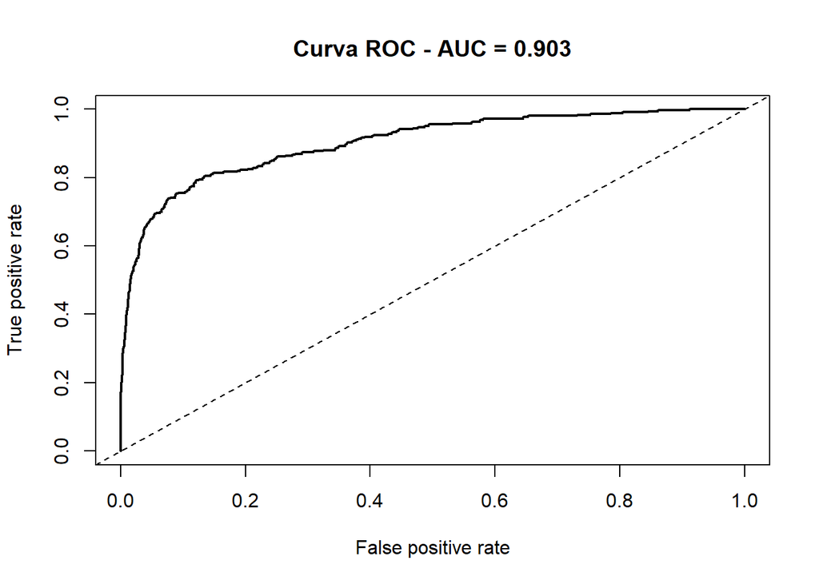

```r
pred1 <- prediction(
  predictions = test_set$pred,
  labels = test_set$BAD
)

perf <- performance(pred1, "tpr", "fpr")
auc <- as.numeric(performance(pred1, "auc")@y.values[[1]])

plot(
  perf,
  main = paste("Curva ROC - AUC =", round(auc, 3)),
  lwd = 2
)
abline(a = 0, b = 1, lty = 2)
```

```r
resumen_metricas <- data.frame(
  Punto_de_corte = corte_final,
  AUC = round(auc, 3),
  Accuracy = round(as.numeric(CM$overall["Accuracy"]), 3),
  Sensitivity = round(as.numeric(CM$byClass["Sensitivity"]), 3),
  Specificity = round(as.numeric(CM$byClass["Specificity"]), 3),
  Precision = round(as.numeric(CM$byClass["Pos Pred Value"]), 3),
  F1_Score = round(as.numeric(CM$byClass["F1"]), 3),
  Balanced_Accuracy = round(as.numeric(CM$byClass["Balanced Accuracy"]), 3)
)

resumen_metricas
```

```
##   Punto_de_corte   AUC Accuracy Sensitivity Specificity Precision F1_Score
## 1            0.5 0.903    0.899       0.656        0.96     0.805    0.723
##   Balanced_Accuracy
## 1             0.808
```

# 8 Conclusión

La limpieza mediante `complete.cases()` generaba un sesgo, porque eliminaba una proporción elevada de casos morosos debido a los valores nulos, especialmente en `DEBTINC`. La imputación por mediana y la inclusión de indicadores de ausencia permiten conservar todos los préstamos con `BAD` conocido y reducir ese problema.

El punto de corte no hace que la muestra sea más equilibrada; modifica la cantidad de préstamos clasificados como morosos. Un corte menor aumenta la sensibilidad, es decir, detecta más morosos, pero reduce la especificidad y aumenta los falsos positivos. Por tanto, la selección del corte debe considerar las métricas observadas y el costo que tendría para una entidad financiera no detectar un préstamo moroso.